# Data Visualisation in R

Anna Skrzydlo

11/30/2021

## Why good data visualisation is important

- Helps understand the data
- Makes it easier to draw conclusions
- Draws attention to what is important in the data
- Makes analysing the data faster (for the audience, once the visual is ready)
- Makes the data easy to digest, especially by the non-analytical audience

## Remove unnecessary elements

The plot below presents the default setting of ggplot.

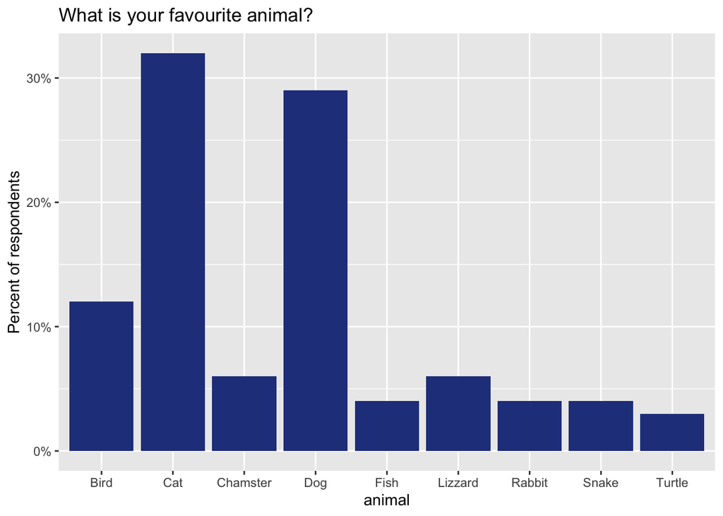

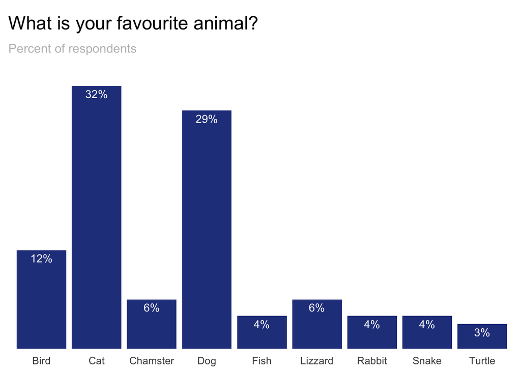

### Your turn!

Modify the graph in order to create decluttered version.

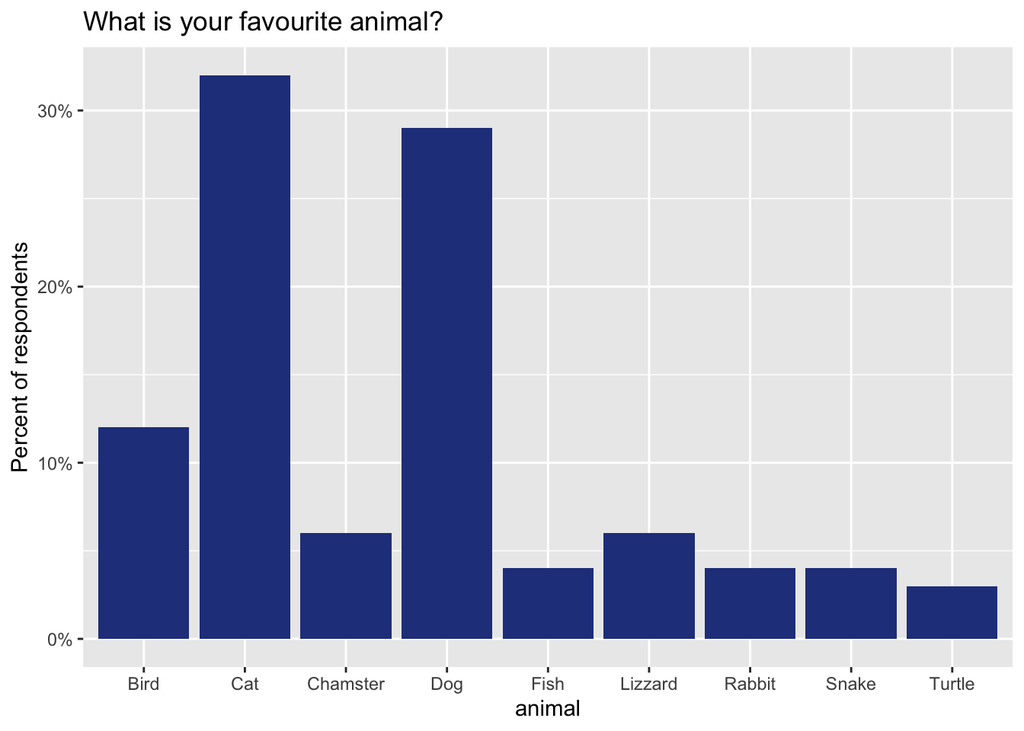

```r
ggplot(data_categories_summarised, aes(x = animal, y = value)) +
  geom_col(fill = 'royalblue4') +
  scale_y_continuous(labels = scales::percent_format(accuracy = 1)) +
  labs(title = element_text("What is your favourite animal?")) +
  ylab("Percent of respondents")
```

## Choose the proper order of the data categories

General rules for ordering:  
1. Natural order (e.g. time)  
2. Meaningful order (e.g. biggest to smallest brand)  
3. Sorted by value (watch out - in applications that refresh the data often it might be misleading)  
4. Alphabetical

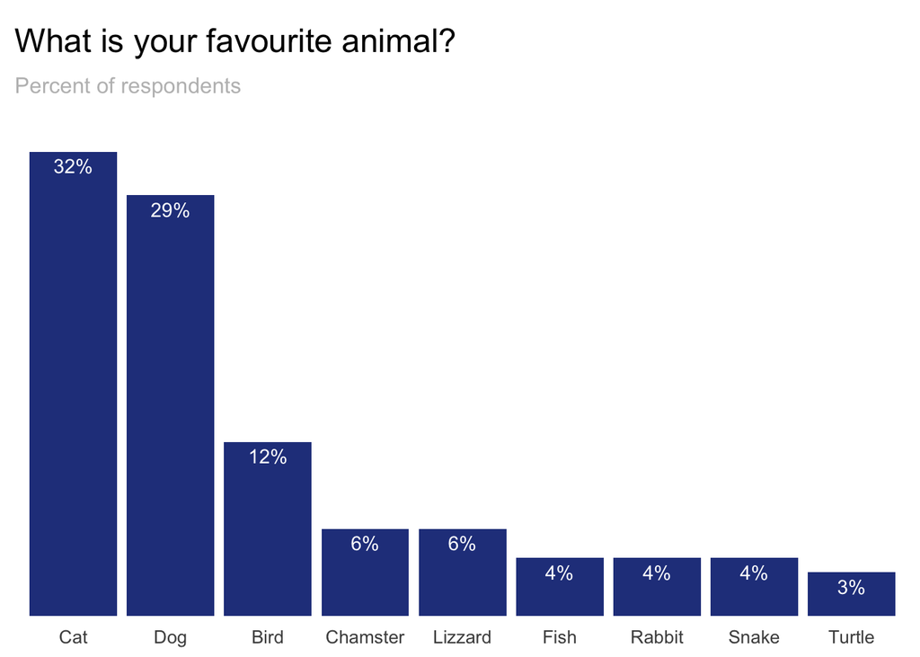

### Your turn!

Modify the graph to order the categories properly.

```r
# Start from the solution to previous task
```

## Don’t ask the user to flip their head - flip the graph

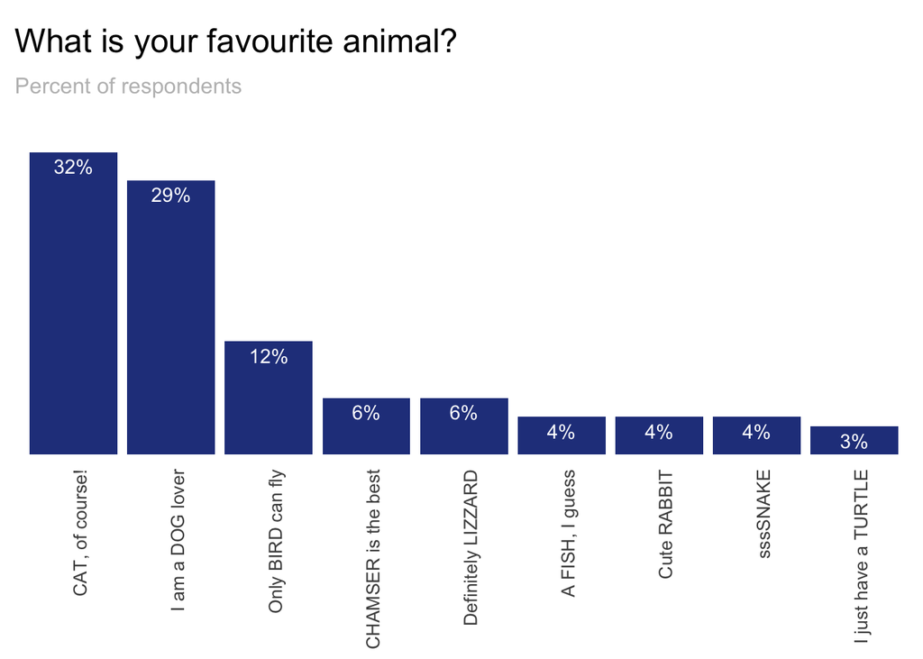

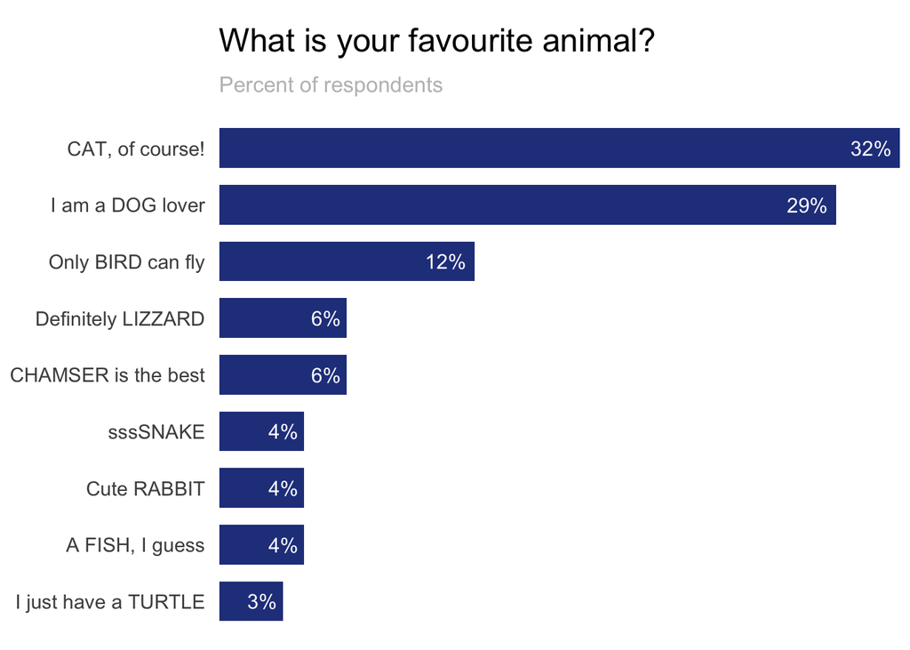

### Your turn!

Flip x and y axis.

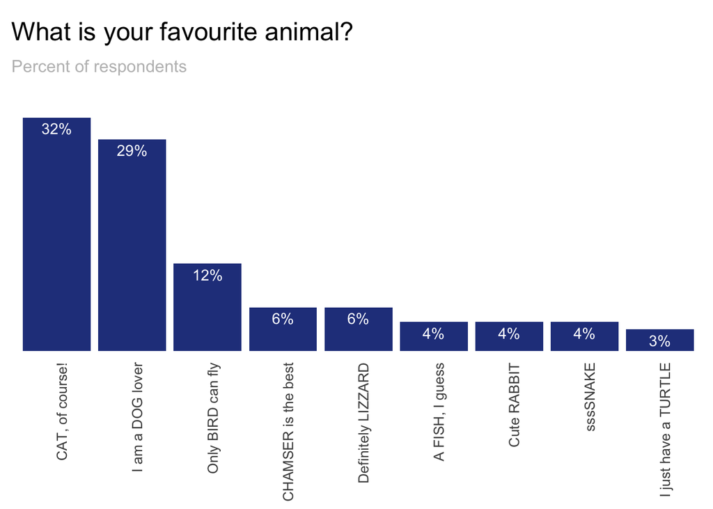

```r
ggplot(data_categories_summarised, aes(x = reorder(animal_long, -value), y = value)) +
  geom_col(fill = "royalblue4") +
  geom_text(aes(label = scales::percent(value, accuracy = 1)), vjust = 1.5, color = "white", size = 3.8) +
  scale_y_continuous(expand = c(0, 0)) +
  labs(title = "What is your favourite animal?",
       subtitle = "Percent of respondents") +
  theme(
    plot.title = element_text(size = 18, margin = margin(10, 0, 0, 0)),
    plot.subtitle = element_text(size = 12, margin = margin(10, 0, 30, 0), color = "gray"),
    panel.background = element_rect(fill = NA),
    panel.grid.major = element_blank(),
    axis.ticks = element_blank(),
    axis.title = element_blank(),
    axis.text.x = element_text(size = 10, margin = margin(5, 0, 0, 0), angle = 90, hjust = 1),
    axis.text.y = element_blank()
  )
```

## Improve a line plot

The graph below shows default settings of a line plot. Decluttering is very similar as for the bar plots.

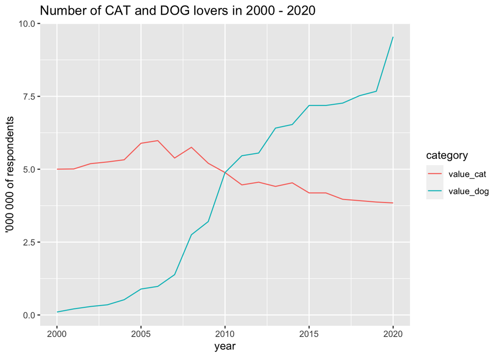

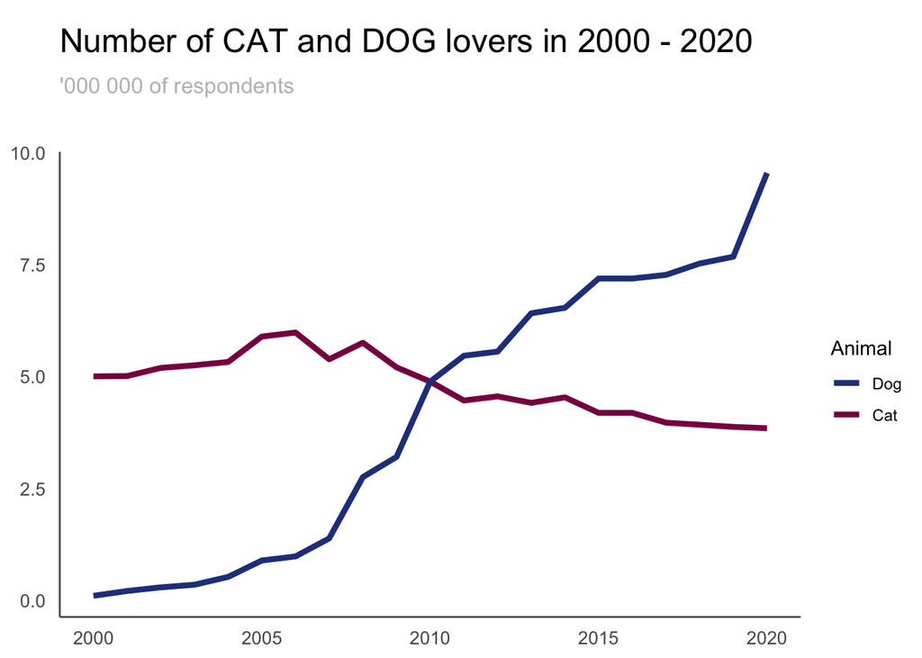

### Your turn!

Modify the graph to create decluttered version.

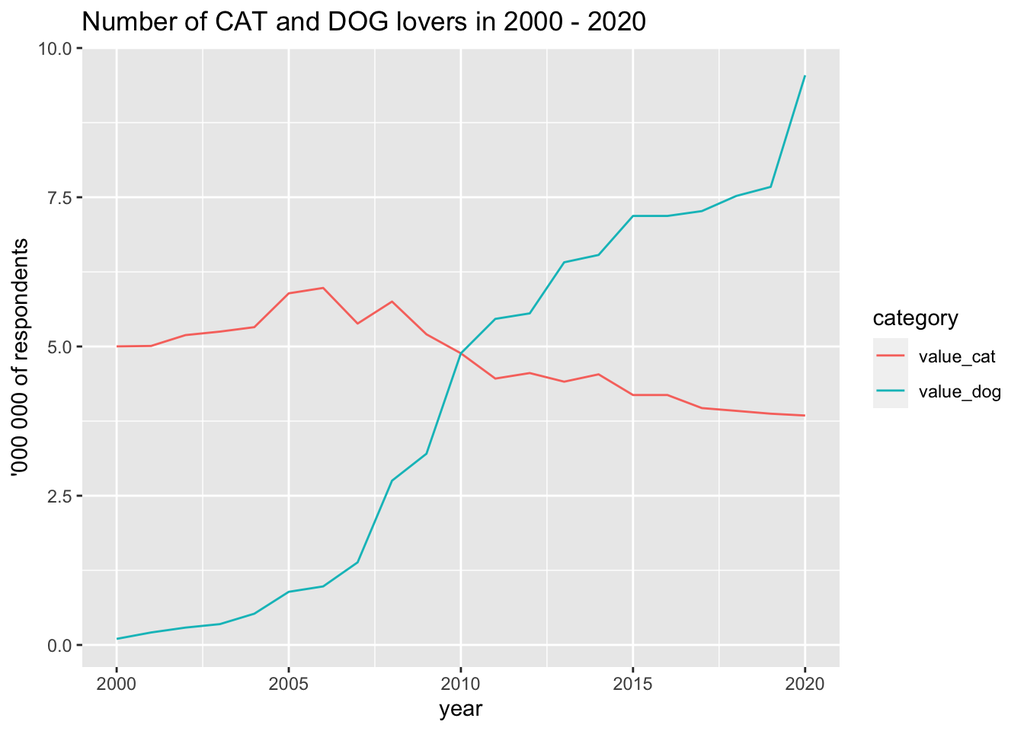

```r
ggplot(data_time_long, aes(x = year, y = value / 1000000)) +
  geom_line(aes(color = category)) +
  labs(title = "Number of CAT and DOG lovers in 2000 - 2020") +
  ylab("'000 000 of respondents")
```

## Put labels close to the data

In order to improve the plot even further you can put the labels next to the data.

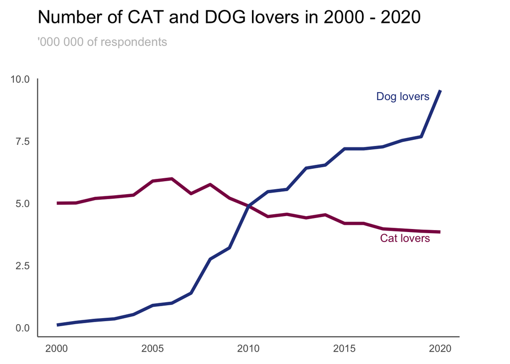

### Your turn!

Modify the graph and put labels next to the data.

```r
# Start from the solution to previous task
```